# Practical Machine Learning - Coursera Project

Utkarsh Yadav

12 November 2016

### Executive Summary

In this project, the data from accelerometers on the belt, forearm, arm, and dumbell of 6 participants has been used. They were asked to perform barbell lifts correctly and incorrectly in 5 different ways.The goal of this project is to:  
a) predict the manner in which they did the exercise by building a model  
b) explain how cross validation has been used  
c) find out expected out of sample rate  
d) use the prediction model to predict 20 different test cases

### Data Import

Here we assume that the required testing & training data has been downloaded & placed in the present working directory.

```r
train<-read.csv("pml-training.csv",na.strings=c("NA","")) #converting all missing values to NA
dim(train)
```

```
## [1] 19622   160
```

```r
test<-read.csv("pml-testing.csv")
dim(test)
```

```
## [1]  20 160
```

### Data Pre-Processing

Since some of the modelling techniques that we are going to deploy (like random forest) would require removal of missing values, we will first remove columns that contain NAs.

```r
train <- train[,sapply(train, function(x) sum(is.na(x))==0)]
dim(train)
```

```
## [1] 19622    60
```

The column dimension reduces to 60 from 160. We further reduce the column dimension to 53 by removing first 7 columns like individual identifiers or timestamps.

```r
train<-train[,-c(1:7)]
dim(train)
```

```
## [1] 19622    53
```

We apply same treatment to test set.

```r
test <- test[,sapply(test, function(x) sum(is.na(x))==0)]
test<-test[,-c(1:7)]
dim(test)
```

```
## [1] 20 53
```

We would like to be sure that the columns in the train & test sets are absolutely same. We check the names of the columns in the reduced sets.

```r
which(names(train)!=names(test))
```

```
## [1] 53
```

The only difference is the column number 53 i.e. column classe in train set & problem_id in test set, which is expected.

### Data Preparation

Now we use this train set to create new subsets for model training & testing purpose.

```r
library(caret)
inTrain<- createDataPartition(y=train$classe,p=0.7,list=FALSE)
newtrain<- train[inTrain,]
newtest <- train[-inTrain,]
```

### Prediction Model

This is a classification problem & we are going to try the following models:  
####1. CART  
For the purpose of cross validation, we would be using 4-fold validation in order to get better estimate of in sample error rate:

```r
library(rpart)
```

```r
mod <- train(classe~.,method="rpart", data=newtrain, trControl=trainControl(method="cv",number=4))
```

The decision tree generated from the model looks like below:

```r
library(rattle)
```

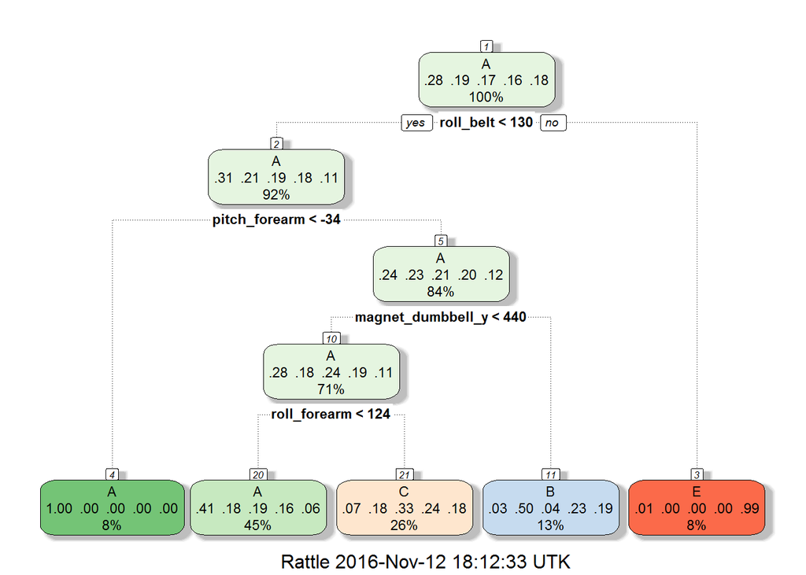

Let us see the out of smaple error of this model

```r
pred <- predict(mod,newtest)
confusionMatrix(pred,newtest$classe)
```

```
## Confusion Matrix and Statistics
##
##           Reference
## Prediction    A    B    C    D    E
##          A 1513  465  447  449  142
##          B   21  406   36  170  149
##          C  133  268  543  345  308
##          D    0    0    0    0    0
##          E    7    0    0    0  483
##
## Overall Statistics
##
##                Accuracy : 0.5004
##                  95% CI : (0.4876, 0.5133)
##     No Information Rate : 0.2845
##     P-Value [Acc > NIR] : < 2.2e-16
##
##                   Kappa : 0.3477
##  Mcnemar's Test P-Value : NA
##
## Statistics by Class:
##
##                      Class: A Class: B Class: C Class: D Class: E
## Sensitivity            0.9038  0.35645  0.52924   0.0000  0.44640
## Specificity            0.6431  0.92078  0.78308   1.0000  0.99854
## Pos Pred Value         0.5017  0.51918  0.34001      NaN  0.98571
## Neg Pred Value         0.9439  0.85636  0.88736   0.8362  0.88897
## Prevalence             0.2845  0.19354  0.17434   0.1638  0.18386
## Detection Rate         0.2571  0.06899  0.09227   0.0000  0.08207
## Detection Prevalence   0.5125  0.13288  0.27137   0.0000  0.08326
## Balanced Accuracy      0.7735  0.63861  0.65616   0.5000  0.72247
```

#### 2. Random Forest(RF)

We will now run RF as our model. We won’t specify cross validation explicity here as RF inherently does cross validation while building the trees.

```r
library(randomForest)
mod1<-train(classe~.,method="rf", data=newtrain)
```

Let us see the out of smaple error for RF

```r
pred1 <- predict(mod1,newtest)
confusionMatrix(pred1,newtest$classe)
```

```
## Confusion Matrix and Statistics
##
##           Reference
## Prediction    A    B    C    D    E
##          A 1673    1    0    0    0
##          B    1 1137    1    0    0
##          C    0    1 1025    6    0
##          D    0    0    0  958    0
##          E    0    0    0    0 1082
##
## Overall Statistics
##
##                Accuracy : 0.9983
##                  95% CI : (0.9969, 0.9992)
##     No Information Rate : 0.2845
##     P-Value [Acc > NIR] : < 2.2e-16
##
##                   Kappa : 0.9979
##  Mcnemar's Test P-Value : NA
##
## Statistics by Class:
##
##                      Class: A Class: B Class: C Class: D Class: E
## Sensitivity            0.9994   0.9982   0.9990   0.9938   1.0000
## Specificity            0.9998   0.9996   0.9986   1.0000   1.0000
## Pos Pred Value         0.9994   0.9982   0.9932   1.0000   1.0000
## Neg Pred Value         0.9998   0.9996   0.9998   0.9988   1.0000
## Prevalence             0.2845   0.1935   0.1743   0.1638   0.1839
## Detection Rate         0.2843   0.1932   0.1742   0.1628   0.1839
## Detection Prevalence   0.2845   0.1935   0.1754   0.1628   0.1839
## Balanced Accuracy      0.9996   0.9989   0.9988   0.9969   1.0000
```

#### 3. Generalized Boosted Regression Model(GBM)

Let us now try GBM as our prediction model. Please note we are not using cross validation here as it takes a very long time to run the model with cross validation. Those having latest configuration machines can icnlude cross validation step.

```r
library(gbm)
mod2<-train(classe~.,method="gbm", data=newtrain)
```

Let us see the out of smaple error for GBM

```r
pred2 <- predict(mod2,newtest)
confusionMatrix(pred2,newtest$classe)
```

```
## Confusion Matrix and Statistics
##
##           Reference
## Prediction    A    B    C    D    E
##          A 1650   28    0    2    2
##          B   15 1086   26    6    6
##          C    5   24  988   26    4
##          D    3    0   11  927    7
##          E    1    1    1    3 1063
##
## Overall Statistics
##
##                Accuracy : 0.9709
##                  95% CI : (0.9663, 0.9751)
##     No Information Rate : 0.2845
##     P-Value [Acc > NIR] : < 2.2e-16
##
##                   Kappa : 0.9632
##  Mcnemar's Test P-Value : 0.001448
##
## Statistics by Class:
##
##                      Class: A Class: B Class: C Class: D Class: E
## Sensitivity            0.9857   0.9535   0.9630   0.9616   0.9824
## Specificity            0.9924   0.9888   0.9879   0.9957   0.9988
## Pos Pred Value         0.9810   0.9535   0.9436   0.9778   0.9944
## Neg Pred Value         0.9943   0.9888   0.9921   0.9925   0.9961
## Prevalence             0.2845   0.1935   0.1743   0.1638   0.1839
## Detection Rate         0.2804   0.1845   0.1679   0.1575   0.1806
## Detection Prevalence   0.2858   0.1935   0.1779   0.1611   0.1816
## Balanced Accuracy      0.9890   0.9712   0.9754   0.9787   0.9906
```

From the above results, we observe, RF is giving us the best accuracy in terms of out os sample error. Hence, we are selecting RF as our model for prediction on the 20 observations shared with us.

### Test Set Prediction

```r
pred3 <- predict(mod1,test)
pred3
```

```
##  [1] B A B A A E D B A A B C B A E E A B B B
## Levels: A B C D E
```